# Sensitivity analyses looking at miss-specification of the effect of statins and antihypertensives

14 July 2026

**Associated manuscript: A flexible approach to sequential prediction under intervention**

These supplementary analyses validate the model under the assumption that the treatment effect of statins and antihypertensives in the validation dataset are 10% and 20% bigger/smaller than those assumed in the development dataset when building the model. We refer to this as a miss-specification of the treatment effect (i.e., the treatment effect in the development dataset has been miss-specified compared to the true effect in the validation dataset).

We multiply the effect of statins or antihypertensives (on the hazard ratio scale) by values of 0.8, 0.9, 1.1 and 1.2. As the hazard ratios are < 1, multipliers 0.8 and 0.9 correspond to a bigger effect in the validation dataset, and multipliers 1.1 and 1.2 correspond to a smaller effect in the validation dataset.

In order to assess the impact of miss-specification, we estimate counterfactual survival times in the validation dataset (see supplementary material for this process) using these miss-specified treatment effects. After this, calibration and discrimination are assessed in the way as described in the main manuscript, and supplementary file 1 (methodology).

In section 1, we report calibration and discrimination in the entire validation dataset, for various levels of miss-specification of the treatment effect of statins/antihypertensives. For calibration, we report calibration curves, and the confidence interval for the calibration curve (note, the confidence intervals in section 1 are very small and so are not visible), and summary metrics ICI, E50 and E90. For discrimination, Harrel's C-index is reported. In section 2, we repeat the analyses within subgroups defined by treatment use (either statins or antihypertensives) at baseline. This is because we expect the biggest effect to be among individuals who are on treatment at baseline. The cohort of individuals off treatment at baseline contains a large number of individuals who never receive any treatment, and are therefore unaffected by the miss-specification.

We always compare calibration and discrimination to the values obtained in the main manuscript, when validating the model assuming the same treatment effects as those used to development to model (no miss-specification).

# 1 Sensitivity analysis in entire validation cohort

When the treatment effects are miss-specified by 10%/20% we see negligible changes to model performance. This will be for two reasons. Firstly, the calibration and discrimination metrics are dominated by low risk individuals who have a small probability of receiving treatment, among whom the impact of miss-specification of the treatment is small. Although, it should be noted that miss-specification seems to have minimal effect among high risk individuals too. This could be partially due to the second reason, which is that the cohort is a mix of individuals on and off treatment at baseline. If equal numbers of individuals start/stop taking treatment during follow-up, the effect of the miss-specification would cancel out. This is why we look at stratified analyses within those on/off treatment at baseline (see section 2).

## 1.1 Women

### 1.1.1 Calibration curves

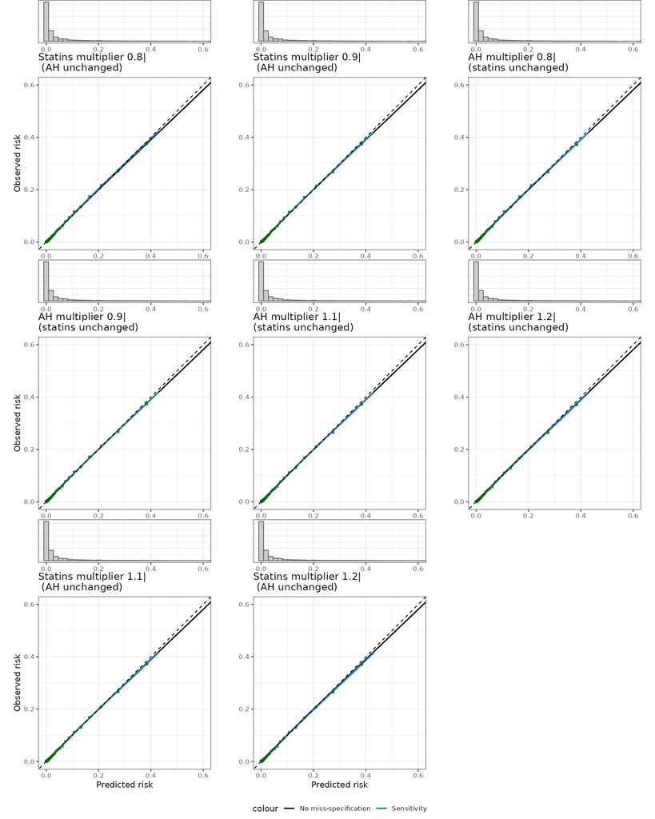

### 1.1.2 Calibration Metrics (ICI, E50, E90)

Calibration metrics for Women. No-miss specification is the value from the main analysis, assuming no miss-specification of the treatment effect

| scenario | metric | value | lower_ci | upper_ci | no miss-specification | difference |
| --- | --- | --- | --- | --- | --- | --- |
| AH multiplier 0.8 (statins unchanged) | ICI | 0.001 | 0.001 | 0.002 | 0.001 | 0.000 |
| AH multiplier 0.9 (statins unchanged) | ICI | 0.001 | 0.001 | 0.001 | 0.001 | 0.000 |
| AH multiplier 1.1 (statins unchanged) | ICI | 0.001 | 0.001 | 0.001 | 0.001 | 0.000 |
| AH multiplier 1.2 (statins unchanged) | ICI | 0.001 | 0.001 | 0.001 | 0.001 | 0.000 |
| Statins multiplier 0.8 (AH unchanged) | ICI | 0.001 | 0.001 | 0.002 | 0.001 | 0.000 |
| Statins multiplier 0.9 (AH unchanged) | ICI | 0.001 | 0.001 | 0.001 | 0.001 | 0.000 |
| Statins multiplier 1.1 (AH unchanged) | ICI | 0.001 | 0.001 | 0.001 | 0.001 | 0.000 |
| Statins multiplier 1.2 (AH unchanged) | ICI | 0.001 | 0.001 | 0.001 | 0.001 | 0.000 |
| AH multiplier 0.8 (statins unchanged) | E50 | 0.001 | 0.000 | 0.001 | 0.001 | 0.000 |
| AH multiplier 0.9 (statins unchanged) | E50 | 0.001 | 0.000 | 0.001 | 0.001 | 0.000 |
| AH multiplier 1.1 (statins unchanged) | E50 | 0.001 | 0.000 | 0.001 | 0.001 | 0.000 |
| AH multiplier 1.2 (statins unchanged) | E50 | 0.000 | 0.000 | 0.001 | 0.001 | 0.000 |
| Statins multiplier 0.8 (AH unchanged) | E50 | 0.001 | 0.000 | 0.001 | 0.001 | 0.000 |
| Statins multiplier 0.9 (AH unchanged) | E50 | 0.001 | 0.000 | 0.001 | 0.001 | 0.000 |
| Statins multiplier 1.1 (AH unchanged) | E50 | 0.001 | 0.000 | 0.001 | 0.001 | 0.000 |
| Statins multiplier 1.2 (AH unchanged) | E50 | 0.001 | 0.000 | 0.001 | 0.001 | 0.000 |
| AH multiplier 0.8 (statins unchanged) | E90 | 0.004 | 0.002 | 0.005 | 0.002 | 0.002 |
| AH multiplier 0.9 (statins unchanged) | E90 | 0.003 | 0.002 | 0.004 | 0.002 | 0.001 |
| AH multiplier 1.1 (statins unchanged) | E90 | 0.001 | 0.001 | 0.003 | 0.002 | -0.001 |
| AH multiplier 1.2 (statins unchanged) | E90 | 0.001 | 0.001 | 0.002 | 0.002 | -0.001 |
| Statins multiplier 0.8 (AH unchanged) | E90 | 0.004 | 0.002 | 0.005 | 0.002 | 0.002 |
| Statins multiplier 0.9 (AH unchanged) | E90 | 0.003 | 0.001 | 0.004 | 0.002 | 0.001 |
| Statins multiplier 1.1 (AH unchanged) | E90 | 0.001 | 0.001 | 0.003 | 0.002 | -0.001 |
| Statins multiplier 1.2 (AH unchanged) | E90 | 0.001 | 0.001 | 0.002 | 0.002 | -0.001 |

### 1.1.3 Discrimination (C-index)

Saved discrimination results for Women. No-miss specification is the value from the main analysis, assuming no miss-specification of the treatment effect.

| scenario | c_index | lower | upper | no miss-specification | difference |
| --- | --- | --- | --- | --- | --- |
| AH multiplier 0.8 (statins unchanged) | 0.872 | 0.872 | 0.872 | 0.871 | 0.000 |
| AH multiplier 0.9 (statins unchanged) | 0.871 | 0.871 | 0.871 | 0.871 | 0.000 |
| AH multiplier 1.1 (statins unchanged) | 0.871 | 0.871 | 0.871 | 0.871 | 0.000 |
| AH multiplier 1.2 (statins unchanged) | 0.871 | 0.871 | 0.871 | 0.871 | 0.000 |
| Statins multiplier 0.8 (AH unchanged) | 0.872 | 0.872 | 0.872 | 0.871 | 0.001 |
| Statins multiplier 0.9 (AH unchanged) | 0.872 | 0.872 | 0.872 | 0.871 | 0.000 |
| Statins multiplier 1.1 (AH unchanged) | 0.871 | 0.871 | 0.871 | 0.871 | 0.000 |
| Statins multiplier 1.2 (AH unchanged) | 0.870 | 0.870 | 0.870 | 0.871 | -0.001 |

## 1.2 Men

### 1.2.1 Calibration curves

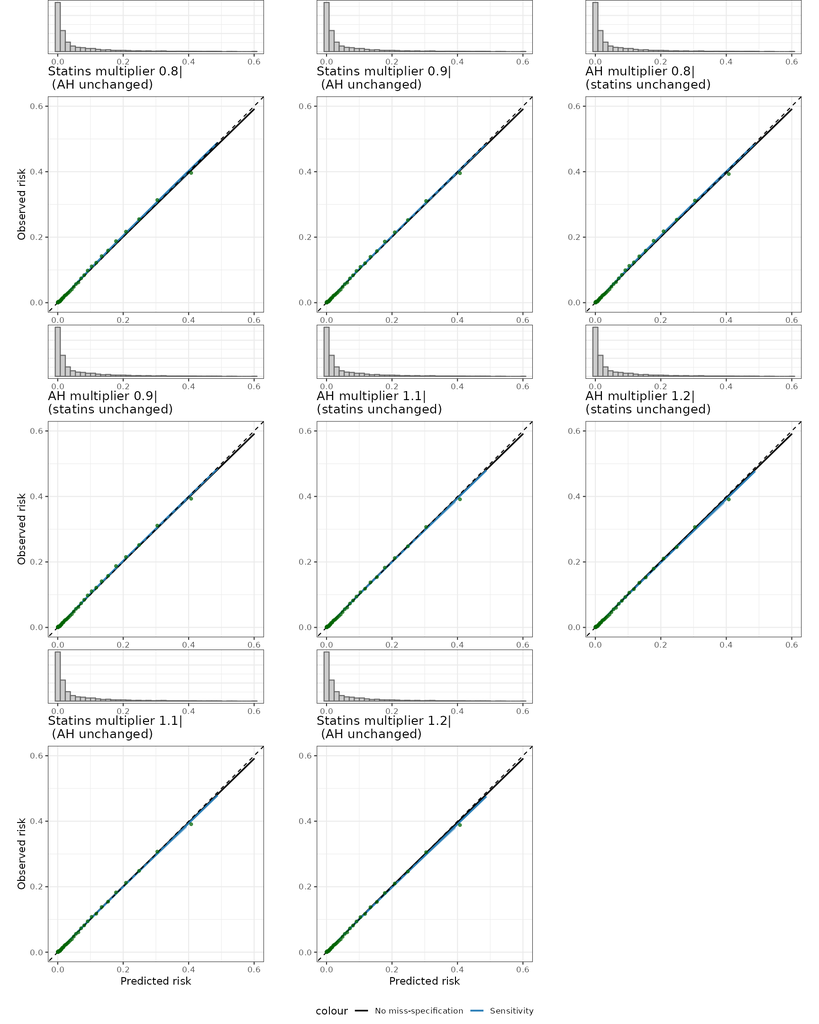

### 1.2.2 Calibration Metrics (ICI, E50, E90)

Calibration metrics for Men. No-miss specification is the value from the main analysis, assuming no miss-specification of the treatment effect

| scenario | metric | value | lower_ci | upper_ci | no miss-specification | difference |
| --- | --- | --- | --- | --- | --- | --- |
| AH multiplier 0.8 (statins unchanged) | ICI | 0.002 | 0.001 | 0.002 | 0.001 | 0.001 |
| AH multiplier 0.9 (statins unchanged) | ICI | 0.001 | 0.001 | 0.002 | 0.001 | 0.000 |
| AH multiplier 1.1 (statins unchanged) | ICI | 0.001 | 0.001 | 0.001 | 0.001 | 0.000 |
| AH multiplier 1.2 (statins unchanged) | ICI | 0.001 | 0.001 | 0.001 | 0.001 | 0.000 |
| Statins multiplier 0.8 (AH unchanged) | ICI | 0.002 | 0.001 | 0.002 | 0.001 | 0.001 |
| Statins multiplier 0.9 (AH unchanged) | ICI | 0.001 | 0.001 | 0.002 | 0.001 | 0.000 |
| Statins multiplier 1.1 (AH unchanged) | ICI | 0.001 | 0.001 | 0.001 | 0.001 | 0.000 |
| Statins multiplier 1.2 (AH unchanged) | ICI | 0.001 | 0.001 | 0.001 | 0.001 | 0.000 |
| AH multiplier 0.8 (statins unchanged) | E50 | 0.001 | 0.000 | 0.001 | 0.001 | 0.000 |
| AH multiplier 0.9 (statins unchanged) | E50 | 0.001 | 0.000 | 0.001 | 0.001 | 0.000 |
| AH multiplier 1.1 (statins unchanged) | E50 | 0.001 | 0.000 | 0.001 | 0.001 | 0.000 |
| AH multiplier 1.2 (statins unchanged) | E50 | 0.000 | 0.000 | 0.001 | 0.001 | 0.000 |
| Statins multiplier 0.8 (AH unchanged) | E50 | 0.001 | 0.001 | 0.001 | 0.001 | 0.000 |
| Statins multiplier 0.9 (AH unchanged) | E50 | 0.001 | 0.000 | 0.001 | 0.001 | 0.000 |
| Statins multiplier 1.1 (AH unchanged) | E50 | 0.001 | 0.000 | 0.001 | 0.001 | 0.000 |
| Statins multiplier 1.2 (AH unchanged) | E50 | 0.001 | 0.000 | 0.001 | 0.001 | 0.000 |
| AH multiplier 0.8 (statins unchanged) | E90 | 0.005 | 0.004 | 0.007 | 0.002 | 0.003 |
| AH multiplier 0.9 (statins unchanged) | E90 | 0.003 | 0.003 | 0.006 | 0.002 | 0.002 |
| AH multiplier 1.1 (statins unchanged) | E90 | 0.001 | 0.001 | 0.003 | 0.002 | -0.001 |
| AH multiplier 1.2 (statins unchanged) | E90 | 0.001 | 0.001 | 0.002 | 0.002 | -0.001 |
| Statins multiplier 0.8 (AH unchanged) | E90 | 0.004 | 0.003 | 0.007 | 0.002 | 0.003 |
| Statins multiplier 0.9 (AH unchanged) | E90 | 0.003 | 0.002 | 0.005 | 0.002 | 0.001 |
| Statins multiplier 1.1 (AH unchanged) | E90 | 0.001 | 0.001 | 0.003 | 0.002 | -0.001 |
| Statins multiplier 1.2 (AH unchanged) | E90 | 0.001 | 0.001 | 0.003 | 0.002 | -0.001 |

### 1.2.3 Discrimination (C-index)

Saved discrimination results for Men. No-miss specification is the value from the main analysis, assuming no miss-specification of the treatment effect.

| scenario | c_index | lower | upper | no miss-specification | difference |
| --- | --- | --- | --- | --- | --- |
| AH multiplier 0.8 (statins unchanged) | 0.855 | 0.855 | 0.855 | 0.854 | 0.001 |
| AH multiplier 0.9 (statins unchanged) | 0.855 | 0.855 | 0.855 | 0.854 | 0.000 |
| AH multiplier 1.1 (statins unchanged) | 0.854 | 0.854 | 0.854 | 0.854 | 0.000 |
| AH multiplier 1.2 (statins unchanged) | 0.853 | 0.853 | 0.853 | 0.854 | -0.001 |
| Statins multiplier 0.8 (AH unchanged) | 0.855 | 0.855 | 0.855 | 0.854 | 0.001 |
| Statins multiplier 0.9 (AH unchanged) | 0.855 | 0.855 | 0.855 | 0.854 | 0.001 |
| Statins multiplier 1.1 (AH unchanged) | 0.854 | 0.854 | 0.854 | 0.854 | 0.000 |
| Statins multiplier 1.2 (AH unchanged) | 0.853 | 0.853 | 0.853 | 0.854 | -0.001 |

# 2 Treatment-stratified sensitivity analysis

As expected, miss-specification of the effects of either statins/anthypertensives has a bigger impact on calibration and discrimination among those on the respective treatment at baseline.

For example, consider section 2.2.1, or 2.6.1. When the effect of statins is bigger in the validation cohort (statins multiplier = 0.8 or 0.9), the calibration curve indicates more over-prediction than the calibration curve under no miss-specification. Similarly, when the effect of statins is smaller in the validation cohort (statins multiplier = 1.1 or 1.2), the calibration curve indicates less over-prediction. Despite this, the magnitude of the difference in the calibration curves is not alarming, and is only visible among higher risk individuals.

Note, the calibration within subgroups defined by treatment use at baseline is imperfect, even when there is no miss-specification of the treatment effect between development and validation. This will largely be due to the fact that statin and antihypertensive use is a strong predictor of incident cardiovascular disease, which have not been used as a predictors in the model. This effect is much stronger for the statin users group (sections 2.2 and 2.6) compared to the antihypertensive users group (sections 2.4 and 2.8), where the model is reasonably well calibrated across the entire distribution of predicted risk. This trade off between predictive performance in the classical sense, and the ability to use the model for prediction under these interventions, is discussed in the main manuscript.

## 2.1 Women - Statins - not on treatment at baseline

### 2.1.1 Calibration curves

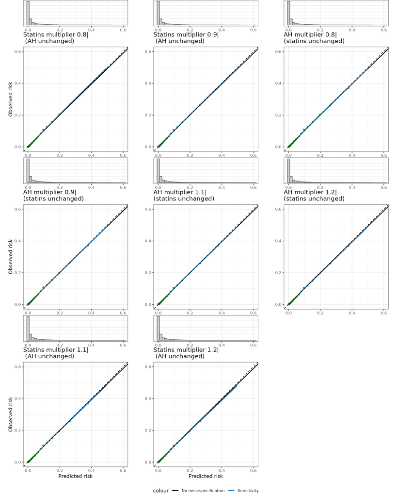

### 2.1.2 Calibration Metrics (ICI, E50, E90)

Saved stratified sensitivity metrics for Women, Statins - not on treatment at baseline. No-miss specification is the value from the main analysis, assuming no miss-specification of the treatment effect, but stratified to the same subgroup.

| scenario | metric | value | no miss-specification | difference |
| --- | --- | --- | --- | --- |
| AH multiplier 0.8 (statins unchanged) | E50 | 0.001 | 0.001 | 0.000 |
| AH multiplier 0.9 (statins unchanged) | E50 | 0.001 | 0.001 | 0.000 |
| AH multiplier 1.1 (statins unchanged) | E50 | 0.001 | 0.001 | 0.000 |
| AH multiplier 1.2 (statins unchanged) | E50 | 0.000 | 0.001 | 0.000 |
| Statins multiplier 0.8 (AH unchanged) | E50 | 0.001 | 0.001 | 0.000 |
| Statins multiplier 0.9 (AH unchanged) | E50 | 0.001 | 0.001 | 0.000 |
| Statins multiplier 1.1 (AH unchanged) | E50 | 0.001 | 0.001 | 0.000 |
| Statins multiplier 1.2 (AH unchanged) | E50 | 0.000 | 0.001 | 0.000 |
| AH multiplier 0.8 (statins unchanged) | E90 | 0.003 | 0.002 | 0.002 |
| AH multiplier 0.9 (statins unchanged) | E90 | 0.003 | 0.002 | 0.001 |
| AH multiplier 1.1 (statins unchanged) | E90 | 0.001 | 0.002 | -0.001 |
| AH multiplier 1.2 (statins unchanged) | E90 | 0.001 | 0.002 | -0.001 |
| Statins multiplier 0.8 (AH unchanged) | E90 | 0.004 | 0.002 | 0.003 |
| Statins multiplier 0.9 (AH unchanged) | E90 | 0.003 | 0.002 | 0.001 |
| Statins multiplier 1.1 (AH unchanged) | E90 | 0.001 | 0.002 | -0.001 |
| Statins multiplier 1.2 (AH unchanged) | E90 | 0.001 | 0.002 | -0.001 |
| AH multiplier 0.8 (statins unchanged) | ICI | 0.001 | 0.001 | 0.000 |
| AH multiplier 0.9 (statins unchanged) | ICI | 0.001 | 0.001 | 0.000 |
| AH multiplier 1.1 (statins unchanged) | ICI | 0.001 | 0.001 | 0.000 |
| AH multiplier 1.2 (statins unchanged) | ICI | 0.001 | 0.001 | 0.000 |
| Statins multiplier 0.8 (AH unchanged) | ICI | 0.001 | 0.001 | 0.000 |
| Statins multiplier 0.9 (AH unchanged) | ICI | 0.001 | 0.001 | 0.000 |
| Statins multiplier 1.1 (AH unchanged) | ICI | 0.001 | 0.001 | 0.000 |
| Statins multiplier 1.2 (AH unchanged) | ICI | 0.001 | 0.001 | 0.000 |

### 2.1.3 Discrimination (C-index)

Saved discrimination results for Women, Statins - not on treatment at baseline. No-miss specification is the value from the main analysis, assuming no miss-specification of the treatment effect, but stratified to the same subgroup.

| scenario | c_index | lower | upper | no miss-specification | difference |
| --- | --- | --- | --- | --- | --- |
| AH multiplier 0.8 (statins unchanged) | 0.874 | 0.874 | 0.874 | 0.873 | 0.001 |
| AH multiplier 0.9 (statins unchanged) | 0.874 | 0.874 | 0.874 | 0.873 | 0.000 |
| AH multiplier 1.1 (statins unchanged) | 0.873 | 0.873 | 0.873 | 0.873 | 0.000 |
| AH multiplier 1.2 (statins unchanged) | 0.873 | 0.873 | 0.873 | 0.873 | -0.001 |
| Statins multiplier 0.8 (AH unchanged) | 0.875 | 0.875 | 0.875 | 0.873 | 0.001 |
| Statins multiplier 0.9 (AH unchanged) | 0.874 | 0.874 | 0.874 | 0.873 | 0.001 |
| Statins multiplier 1.1 (AH unchanged) | 0.873 | 0.873 | 0.873 | 0.873 | -0.001 |
| Statins multiplier 1.2 (AH unchanged) | 0.872 | 0.872 | 0.872 | 0.873 | -0.001 |

## 2.2 Women - Statins - on treatment at baseline

### 2.2.1 Calibration curves

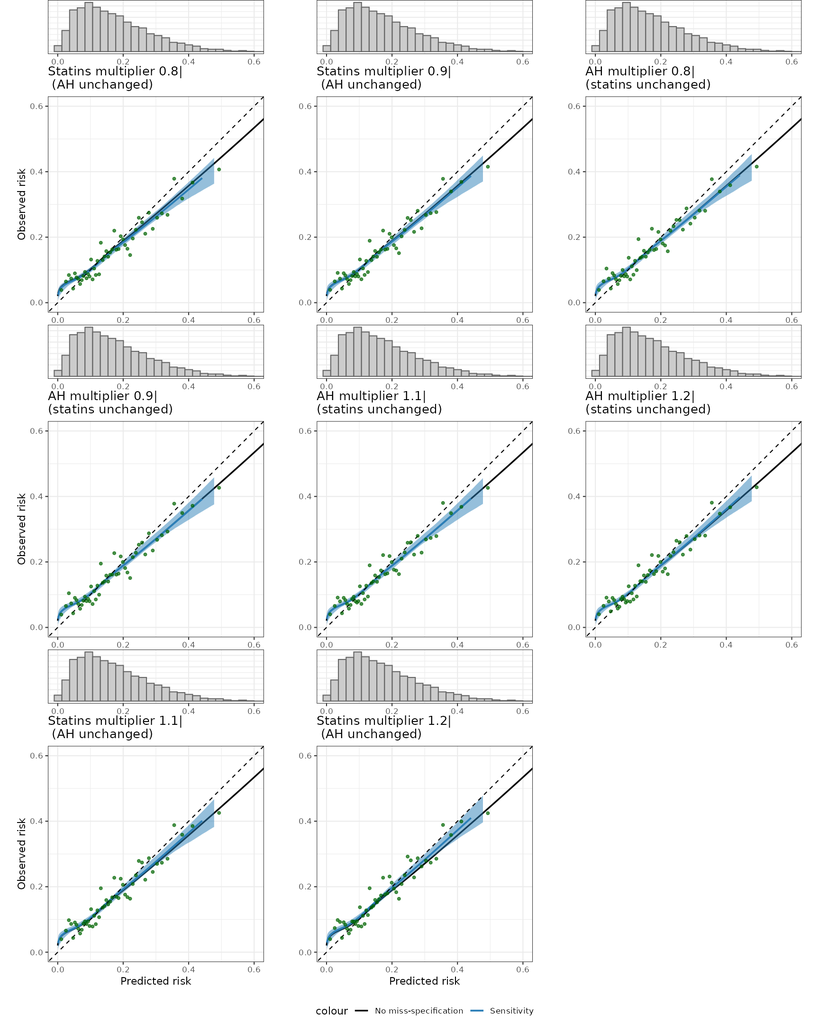

### 2.2.2 Calibration Metrics (ICI, E50, E90)

Saved stratified sensitivity metrics for Women, Statins - on treatment at baseline. No-miss specification is the value from the main analysis, assuming no miss-specification of the treatment effect, but stratified to the same subgroup.

| scenario | metric | value | no miss-specification | difference |
| --- | --- | --- | --- | --- |
| AH multiplier 0.8 (statins unchanged) | E50 | 0.012 | 0.012 | 0.000 |
| AH multiplier 0.9 (statins unchanged) | E50 | 0.012 | 0.012 | 0.000 |
| AH multiplier 1.1 (statins unchanged) | E50 | 0.012 | 0.012 | 0.000 |
| AH multiplier 1.2 (statins unchanged) | E50 | 0.012 | 0.012 | -0.001 |
| Statins multiplier 0.8 (AH unchanged) | E50 | 0.014 | 0.012 | 0.002 |
| Statins multiplier 0.9 (AH unchanged) | E50 | 0.013 | 0.012 | 0.001 |
| Statins multiplier 1.1 (AH unchanged) | E50 | 0.011 | 0.012 | -0.002 |
| Statins multiplier 1.2 (AH unchanged) | E50 | 0.010 | 0.012 | -0.003 |
| AH multiplier 0.8 (statins unchanged) | E90 | 0.037 | 0.036 | 0.001 |
| AH multiplier 0.9 (statins unchanged) | E90 | 0.036 | 0.036 | 0.000 |
| AH multiplier 1.1 (statins unchanged) | E90 | 0.035 | 0.036 | 0.000 |
| AH multiplier 1.2 (statins unchanged) | E90 | 0.034 | 0.036 | -0.002 |
| Statins multiplier 0.8 (AH unchanged) | E90 | 0.042 | 0.036 | 0.006 |
| Statins multiplier 0.9 (AH unchanged) | E90 | 0.037 | 0.036 | 0.002 |
| Statins multiplier 1.1 (AH unchanged) | E90 | 0.032 | 0.036 | -0.003 |
| Statins multiplier 1.2 (AH unchanged) | E90 | 0.029 | 0.036 | -0.007 |
| AH multiplier 0.8 (statins unchanged) | ICI | 0.016 | 0.016 | 0.001 |
| AH multiplier 0.9 (statins unchanged) | ICI | 0.016 | 0.016 | 0.000 |
| AH multiplier 1.1 (statins unchanged) | ICI | 0.016 | 0.016 | 0.000 |
| AH multiplier 1.2 (statins unchanged) | ICI | 0.015 | 0.016 | -0.001 |
| Statins multiplier 0.8 (AH unchanged) | ICI | 0.019 | 0.016 | 0.003 |
| Statins multiplier 0.9 (AH unchanged) | ICI | 0.017 | 0.016 | 0.001 |
| Statins multiplier 1.1 (AH unchanged) | ICI | 0.014 | 0.016 | -0.002 |
| Statins multiplier 1.2 (AH unchanged) | ICI | 0.013 | 0.016 | -0.003 |

### 2.2.3 Discrimination (C-index)

Saved discrimination results for Women, Statins - on treatment at baseline. No-miss specification is the value from the main analysis, assuming no miss-specification of the treatment effect, but stratified to the same subgroup.

| scenario | c_index | lower | upper | no miss-specification | difference |
| --- | --- | --- | --- | --- | --- |
| AH multiplier 0.8 (statins unchanged) | 0.659 | 0.658 | 0.659 | 0.66 | -0.001 |
| AH multiplier 0.9 (statins unchanged) | 0.659 | 0.659 | 0.659 | 0.66 | -0.001 |
| AH multiplier 1.1 (statins unchanged) | 0.660 | 0.660 | 0.660 | 0.66 | 0.000 |
| AH multiplier 1.2 (statins unchanged) | 0.661 | 0.660 | 0.661 | 0.66 | 0.001 |
| Statins multiplier 0.8 (AH unchanged) | 0.660 | 0.660 | 0.660 | 0.66 | 0.000 |
| Statins multiplier 0.9 (AH unchanged) | 0.660 | 0.660 | 0.660 | 0.66 | 0.000 |
| Statins multiplier 1.1 (AH unchanged) | 0.659 | 0.659 | 0.660 | 0.66 | 0.000 |
| Statins multiplier 1.2 (AH unchanged) | 0.659 | 0.659 | 0.659 | 0.66 | 0.000 |

## 2.3 Women - antihypertensives - not on treatment at baseline

### 2.3.1 Calibration curves

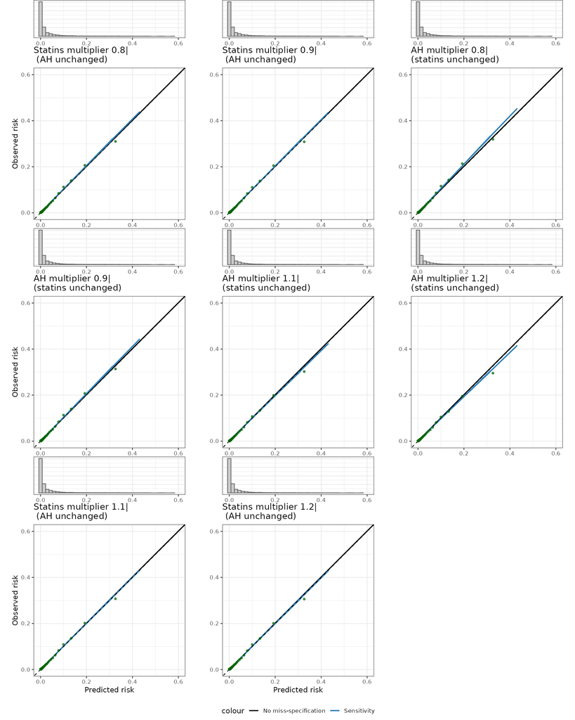

### 2.3.2 Calibration Metrics (ICI, E50, E90)

Saved stratified sensitivity metrics for Women, antihypertensives - not on treatment at baseline. No-miss specification is the value from the main analysis, assuming no miss-specification of the treatment effect, but stratified to the same subgroup.

| scenario | metric | value | no miss-specification | difference |
| --- | --- | --- | --- | --- |
| AH multiplier 0.8 (statins unchanged) | E50 | 0.001 | 0.001 | 0.000 |
| AH multiplier 0.9 (statins unchanged) | E50 | 0.001 | 0.001 | 0.000 |
| AH multiplier 1.1 (statins unchanged) | E50 | 0.001 | 0.001 | 0.000 |
| AH multiplier 1.2 (statins unchanged) | E50 | 0.001 | 0.001 | 0.000 |
| Statins multiplier 0.8 (AH unchanged) | E50 | 0.001 | 0.001 | 0.000 |
| Statins multiplier 0.9 (AH unchanged) | E50 | 0.001 | 0.001 | 0.000 |
| Statins multiplier 1.1 (AH unchanged) | E50 | 0.000 | 0.001 | 0.000 |
| Statins multiplier 1.2 (AH unchanged) | E50 | 0.000 | 0.001 | 0.000 |
| AH multiplier 0.8 (statins unchanged) | E90 | 0.004 | 0.001 | 0.003 |
| AH multiplier 0.9 (statins unchanged) | E90 | 0.002 | 0.001 | 0.001 |
| AH multiplier 1.1 (statins unchanged) | E90 | 0.001 | 0.001 | 0.000 |
| AH multiplier 1.2 (statins unchanged) | E90 | 0.001 | 0.001 | 0.001 |
| Statins multiplier 0.8 (AH unchanged) | E90 | 0.002 | 0.001 | 0.001 |
| Statins multiplier 0.9 (AH unchanged) | E90 | 0.002 | 0.001 | 0.001 |
| Statins multiplier 1.1 (AH unchanged) | E90 | 0.001 | 0.001 | 0.000 |
| Statins multiplier 1.2 (AH unchanged) | E90 | 0.001 | 0.001 | 0.000 |
| AH multiplier 0.8 (statins unchanged) | ICI | 0.001 | 0.001 | 0.001 |
| AH multiplier 0.9 (statins unchanged) | ICI | 0.001 | 0.001 | 0.000 |
| AH multiplier 1.1 (statins unchanged) | ICI | 0.001 | 0.001 | 0.000 |
| AH multiplier 1.2 (statins unchanged) | ICI | 0.001 | 0.001 | 0.000 |
| Statins multiplier 0.8 (AH unchanged) | ICI | 0.001 | 0.001 | 0.000 |
| Statins multiplier 0.9 (AH unchanged) | ICI | 0.001 | 0.001 | 0.000 |
| Statins multiplier 1.1 (AH unchanged) | ICI | 0.000 | 0.001 | 0.000 |
| Statins multiplier 1.2 (AH unchanged) | ICI | 0.000 | 0.001 | 0.000 |

### 2.3.3 Discrimination (C-index)

Saved discrimination results for Women, antihypertensives - not on treatment at baseline. No-miss specification is the value from the main analysis, assuming no miss-specification of the treatment effect, but stratified to the same subgroup.

| scenario | c_index | lower | upper | no miss-specification | difference |
| --- | --- | --- | --- | --- | --- |
| AH multiplier 0.8 (statins unchanged) | 0.876 | 0.876 | 0.876 | 0.873 | 0.002 |
| AH multiplier 0.9 (statins unchanged) | 0.875 | 0.875 | 0.875 | 0.873 | 0.001 |
| AH multiplier 1.1 (statins unchanged) | 0.872 | 0.872 | 0.872 | 0.873 | -0.001 |
| AH multiplier 1.2 (statins unchanged) | 0.871 | 0.871 | 0.871 | 0.873 | -0.002 |
| Statins multiplier 0.8 (AH unchanged) | 0.874 | 0.874 | 0.874 | 0.873 | 0.001 |
| Statins multiplier 0.9 (AH unchanged) | 0.874 | 0.874 | 0.874 | 0.873 | 0.000 |
| Statins multiplier 1.1 (AH unchanged) | 0.873 | 0.873 | 0.873 | 0.873 | 0.000 |
| Statins multiplier 1.2 (AH unchanged) | 0.873 | 0.873 | 0.873 | 0.873 | -0.001 |

## 2.4 Women - antihypertensives - on treatment at baseline

### 2.4.1 Calibration curves

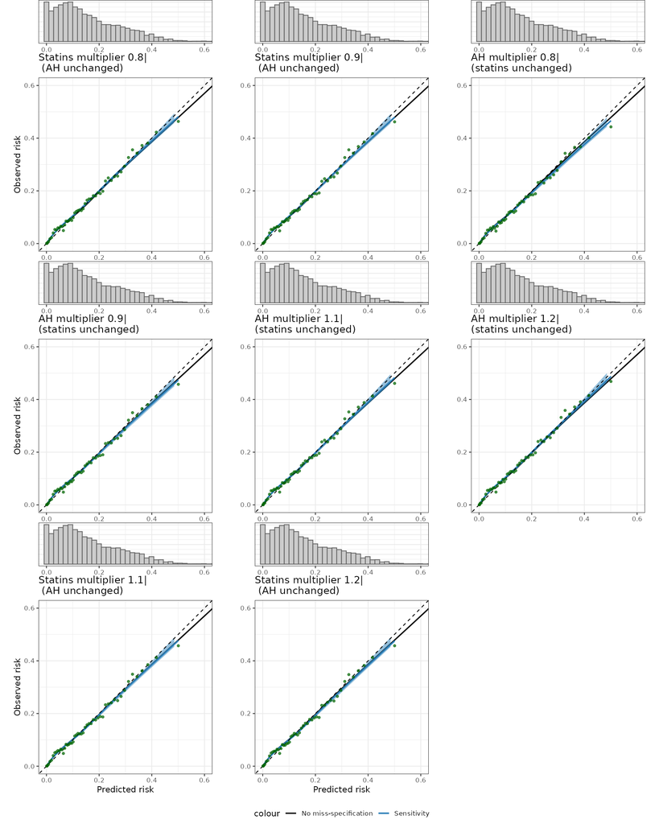

### 2.4.2 Calibration Metrics (ICI, E50, E90)

Saved stratified sensitivity metrics for Women, antihypertensives - on treatment at baseline. No-miss specification is the value from the main analysis, assuming no miss-specification of the treatment effect, but stratified to the same subgroup.

| scenario | metric | value | no miss-specification | difference |
| --- | --- | --- | --- | --- |
| AH multiplier 0.8 (statins unchanged) | E50 | 0.007 | 0.004 | 0.004 |
| AH multiplier 0.9 (statins unchanged) | E50 | 0.005 | 0.004 | 0.001 |
| AH multiplier 1.1 (statins unchanged) | E50 | 0.003 | 0.004 | -0.001 |
| AH multiplier 1.2 (statins unchanged) | E50 | 0.002 | 0.004 | -0.002 |
| Statins multiplier 0.8 (AH unchanged) | E50 | 0.003 | 0.004 | -0.001 |
| Statins multiplier 0.9 (AH unchanged) | E50 | 0.003 | 0.004 | -0.001 |
| Statins multiplier 1.1 (AH unchanged) | E50 | 0.005 | 0.004 | 0.002 |
| Statins multiplier 1.2 (AH unchanged) | E50 | 0.007 | 0.004 | 0.003 |
| AH multiplier 0.8 (statins unchanged) | E90 | 0.016 | 0.010 | 0.006 |
| AH multiplier 0.9 (statins unchanged) | E90 | 0.011 | 0.010 | 0.001 |
| AH multiplier 1.1 (statins unchanged) | E90 | 0.010 | 0.010 | 0.000 |
| AH multiplier 1.2 (statins unchanged) | E90 | 0.011 | 0.010 | 0.001 |
| Statins multiplier 0.8 (AH unchanged) | E90 | 0.011 | 0.010 | 0.001 |
| Statins multiplier 0.9 (AH unchanged) | E90 | 0.010 | 0.010 | 0.000 |
| Statins multiplier 1.1 (AH unchanged) | E90 | 0.010 | 0.010 | 0.000 |
| Statins multiplier 1.2 (AH unchanged) | E90 | 0.012 | 0.010 | 0.002 |
| AH multiplier 0.8 (statins unchanged) | ICI | 0.008 | 0.006 | 0.003 |
| AH multiplier 0.9 (statins unchanged) | ICI | 0.007 | 0.006 | 0.001 |
| AH multiplier 1.1 (statins unchanged) | ICI | 0.005 | 0.006 | -0.001 |
| AH multiplier 1.2 (statins unchanged) | ICI | 0.004 | 0.006 | -0.001 |
| Statins multiplier 0.8 (AH unchanged) | ICI | 0.005 | 0.006 | -0.001 |
| Statins multiplier 0.9 (AH unchanged) | ICI | 0.005 | 0.006 | -0.001 |
| Statins multiplier 1.1 (AH unchanged) | ICI | 0.006 | 0.006 | 0.001 |
| Statins multiplier 1.2 (AH unchanged) | ICI | 0.007 | 0.006 | 0.002 |

### 2.4.3 Discrimination (C-index)

Saved discrimination results for Women, antihypertensives - on treatment at baseline. No-miss specification is the value from the main analysis, assuming no miss-specification of the treatment effect, but stratified to the same subgroup.

| scenario | c_index | lower | upper | no miss-specification | difference |
| --- | --- | --- | --- | --- | --- |
| AH multiplier 0.8 (statins unchanged) | 0.713 | 0.713 | 0.713 | 0.711 | 0.001 |
| AH multiplier 0.9 (statins unchanged) | 0.712 | 0.712 | 0.712 | 0.711 | 0.001 |
| AH multiplier 1.1 (statins unchanged) | 0.710 | 0.710 | 0.710 | 0.711 | -0.001 |
| AH multiplier 1.2 (statins unchanged) | 0.710 | 0.710 | 0.710 | 0.711 | -0.001 |
| Statins multiplier 0.8 (AH unchanged) | 0.711 | 0.711 | 0.711 | 0.711 | 0.000 |
| Statins multiplier 0.9 (AH unchanged) | 0.711 | 0.711 | 0.711 | 0.711 | 0.000 |
| Statins multiplier 1.1 (AH unchanged) | 0.711 | 0.711 | 0.711 | 0.711 | 0.000 |
| Statins multiplier 1.2 (AH unchanged) | 0.711 | 0.711 | 0.711 | 0.711 | 0.000 |

## 2.5 Men - Statins - not on treatment at baseline

### 2.5.1 Calibration curves

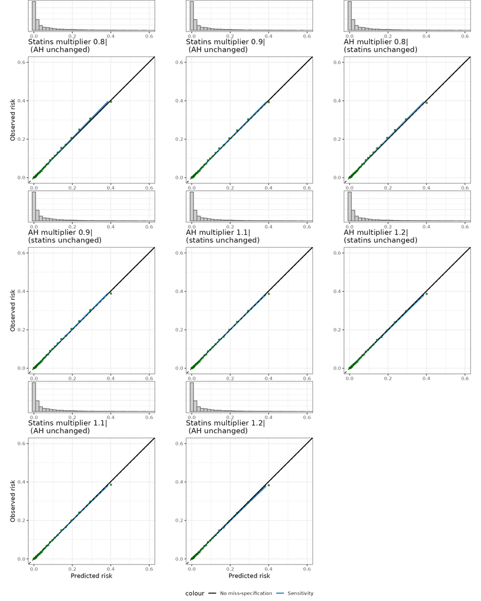

### 2.5.2 Calibration Metrics (ICI, E50, E90)

Saved stratified sensitivity metrics for Men, Statins - not on treatment at baseline. No-miss specification is the value from the main analysis, assuming no miss-specification of the treatment effect, but stratified to the same subgroup.

| scenario | metric | value | no miss-specification | difference |
| --- | --- | --- | --- | --- |
| AH multiplier 0.8 (statins unchanged) | E50 | 0.001 | 0.001 | 0.000 |
| AH multiplier 0.9 (statins unchanged) | E50 | 0.001 | 0.001 | 0.000 |
| AH multiplier 1.1 (statins unchanged) | E50 | 0.000 | 0.001 | 0.000 |
| AH multiplier 1.2 (statins unchanged) | E50 | 0.001 | 0.001 | 0.000 |
| Statins multiplier 0.8 (AH unchanged) | E50 | 0.001 | 0.001 | 0.000 |
| Statins multiplier 0.9 (AH unchanged) | E50 | 0.001 | 0.001 | 0.000 |
| Statins multiplier 1.1 (AH unchanged) | E50 | 0.000 | 0.001 | 0.000 |
| Statins multiplier 1.2 (AH unchanged) | E50 | 0.001 | 0.001 | 0.000 |
| AH multiplier 0.8 (statins unchanged) | E90 | 0.005 | 0.002 | 0.003 |
| AH multiplier 0.9 (statins unchanged) | E90 | 0.003 | 0.002 | 0.002 |
| AH multiplier 1.1 (statins unchanged) | E90 | 0.001 | 0.002 | -0.001 |
| AH multiplier 1.2 (statins unchanged) | E90 | 0.001 | 0.002 | 0.000 |
| Statins multiplier 0.8 (AH unchanged) | E90 | 0.005 | 0.002 | 0.004 |
| Statins multiplier 0.9 (AH unchanged) | E90 | 0.003 | 0.002 | 0.002 |
| Statins multiplier 1.1 (AH unchanged) | E90 | 0.001 | 0.002 | -0.001 |
| Statins multiplier 1.2 (AH unchanged) | E90 | 0.002 | 0.002 | 0.000 |
| AH multiplier 0.8 (statins unchanged) | ICI | 0.002 | 0.001 | 0.001 |
| AH multiplier 0.9 (statins unchanged) | ICI | 0.001 | 0.001 | 0.000 |
| AH multiplier 1.1 (statins unchanged) | ICI | 0.000 | 0.001 | 0.000 |
| AH multiplier 1.2 (statins unchanged) | ICI | 0.001 | 0.001 | 0.000 |
| Statins multiplier 0.8 (AH unchanged) | ICI | 0.002 | 0.001 | 0.001 |
| Statins multiplier 0.9 (AH unchanged) | ICI | 0.001 | 0.001 | 0.000 |
| Statins multiplier 1.1 (AH unchanged) | ICI | 0.000 | 0.001 | 0.000 |
| Statins multiplier 1.2 (AH unchanged) | ICI | 0.001 | 0.001 | 0.000 |

### 2.5.3 Discrimination (C-index)

Saved discrimination results for Men, Statins - not on treatment at baseline. No-miss specification is the value from the main analysis, assuming no miss-specification of the treatment effect, but stratified to the same subgroup.

| scenario | c_index | lower | upper | no miss-specification | difference |
| --- | --- | --- | --- | --- | --- |
| AH multiplier 0.8 (statins unchanged) | 0.858 | 0.858 | 0.858 | 0.857 | 0.001 |
| AH multiplier 0.9 (statins unchanged) | 0.857 | 0.857 | 0.857 | 0.857 | 0.001 |
| AH multiplier 1.1 (statins unchanged) | 0.856 | 0.856 | 0.856 | 0.857 | -0.001 |
| AH multiplier 1.2 (statins unchanged) | 0.856 | 0.856 | 0.856 | 0.857 | -0.001 |
| Statins multiplier 0.8 (AH unchanged) | 0.858 | 0.858 | 0.858 | 0.857 | 0.001 |
| Statins multiplier 0.9 (AH unchanged) | 0.857 | 0.857 | 0.857 | 0.857 | 0.001 |
| Statins multiplier 1.1 (AH unchanged) | 0.856 | 0.856 | 0.856 | 0.857 | -0.001 |
| Statins multiplier 1.2 (AH unchanged) | 0.855 | 0.855 | 0.855 | 0.857 | -0.001 |

## 2.6 Men - Statins - on treatment at baseline

### 2.6.1 Calibration curves

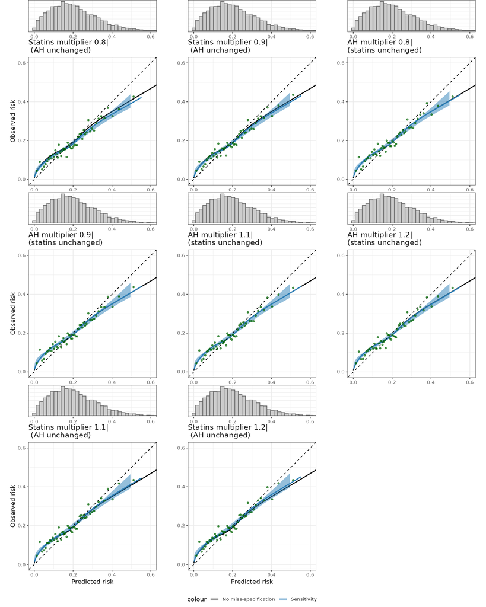

### 2.6.2 Calibration Metrics (ICI, E50, E90)

Saved stratified sensitivity metrics for Men, Statins - on treatment at baseline. No-miss specification is the value from the main analysis, assuming no miss-specification of the treatment effect, but stratified to the same subgroup.

| scenario | metric | value | no miss-specification | difference |
| --- | --- | --- | --- | --- |
| AH multiplier 0.8 (statins unchanged) | E50 | 0.016 | 0.016 | 0.000 |
| AH multiplier 0.9 (statins unchanged) | E50 | 0.016 | 0.016 | 0.000 |
| AH multiplier 1.1 (statins unchanged) | E50 | 0.016 | 0.016 | 0.000 |
| AH multiplier 1.2 (statins unchanged) | E50 | 0.017 | 0.016 | 0.001 |
| Statins multiplier 0.8 (AH unchanged) | E50 | 0.021 | 0.016 | 0.005 |
| Statins multiplier 0.9 (AH unchanged) | E50 | 0.018 | 0.016 | 0.002 |
| Statins multiplier 1.1 (AH unchanged) | E50 | 0.015 | 0.016 | -0.001 |
| Statins multiplier 1.2 (AH unchanged) | E50 | 0.014 | 0.016 | -0.002 |
| AH multiplier 0.8 (statins unchanged) | E90 | 0.042 | 0.042 | 0.001 |
| AH multiplier 0.9 (statins unchanged) | E90 | 0.042 | 0.042 | 0.001 |
| AH multiplier 1.1 (statins unchanged) | E90 | 0.041 | 0.042 | 0.000 |
| AH multiplier 1.2 (statins unchanged) | E90 | 0.040 | 0.042 | -0.001 |
| Statins multiplier 0.8 (AH unchanged) | E90 | 0.046 | 0.042 | 0.004 |
| Statins multiplier 0.9 (AH unchanged) | E90 | 0.040 | 0.042 | -0.002 |
| Statins multiplier 1.1 (AH unchanged) | E90 | 0.043 | 0.042 | 0.002 |
| Statins multiplier 1.2 (AH unchanged) | E90 | 0.045 | 0.042 | 0.004 |
| AH multiplier 0.8 (statins unchanged) | ICI | 0.023 | 0.023 | 0.000 |
| AH multiplier 0.9 (statins unchanged) | ICI | 0.022 | 0.023 | 0.000 |
| AH multiplier 1.1 (statins unchanged) | ICI | 0.023 | 0.023 | 0.000 |
| AH multiplier 1.2 (statins unchanged) | ICI | 0.023 | 0.023 | 0.001 |
| Statins multiplier 0.8 (AH unchanged) | ICI | 0.026 | 0.023 | 0.004 |
| Statins multiplier 0.9 (AH unchanged) | ICI | 0.025 | 0.023 | 0.002 |
| Statins multiplier 1.1 (AH unchanged) | ICI | 0.022 | 0.023 | -0.001 |
| Statins multiplier 1.2 (AH unchanged) | ICI | 0.021 | 0.023 | -0.002 |

### 2.6.3 Discrimination (C-index)

Saved discrimination results for Men, Statins - on treatment at baseline. No-miss specification is the value from the main analysis, assuming no miss-specification of the treatment effect, but stratified to the same subgroup.

| scenario | c_index | lower | upper | no miss-specification | difference |
| --- | --- | --- | --- | --- | --- |
| AH multiplier 0.8 (statins unchanged) | 0.630 | 0.630 | 0.630 | 0.631 | -0.001 |
| AH multiplier 0.9 (statins unchanged) | 0.630 | 0.630 | 0.631 | 0.631 | 0.000 |
| AH multiplier 1.1 (statins unchanged) | 0.631 | 0.631 | 0.631 | 0.631 | 0.000 |
| AH multiplier 1.2 (statins unchanged) | 0.631 | 0.631 | 0.631 | 0.631 | 0.001 |
| Statins multiplier 0.8 (AH unchanged) | 0.632 | 0.632 | 0.632 | 0.631 | 0.001 |
| Statins multiplier 0.9 (AH unchanged) | 0.631 | 0.631 | 0.632 | 0.631 | 0.001 |
| Statins multiplier 1.1 (AH unchanged) | 0.630 | 0.630 | 0.630 | 0.631 | -0.001 |
| Statins multiplier 1.2 (AH unchanged) | 0.630 | 0.629 | 0.630 | 0.631 | -0.001 |

## 2.7 Men - antihypertensives - not on treatment at baseline

### 2.7.1 Calibration curves

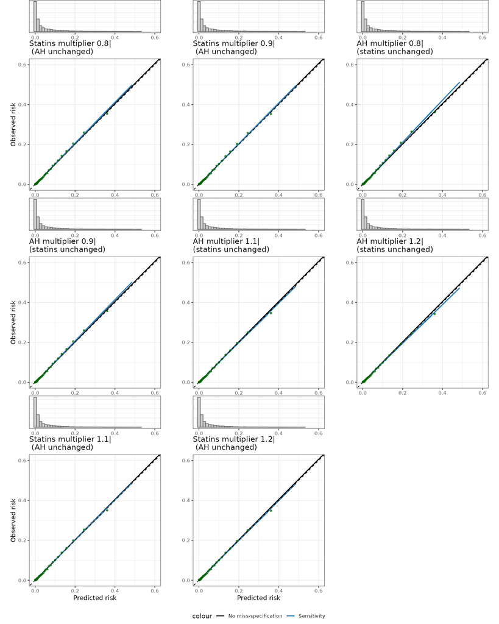

### 2.7.2 Calibration Metrics (ICI, E50, E90)

Saved stratified sensitivity metrics for Men, antihypertensives - not on treatment at baseline. No-miss specification is the value from the main analysis, assuming no miss-specification of the treatment effect, but stratified to the same subgroup.

| scenario | metric | value | no miss-specification | difference |
| --- | --- | --- | --- | --- |
| AH multiplier 0.8 (statins unchanged) | E50 | 0.001 | 0.001 | 0.000 |
| AH multiplier 0.9 (statins unchanged) | E50 | 0.001 | 0.001 | 0.000 |
| AH multiplier 1.1 (statins unchanged) | E50 | 0.001 | 0.001 | 0.000 |
| AH multiplier 1.2 (statins unchanged) | E50 | 0.001 | 0.001 | 0.000 |
| Statins multiplier 0.8 (AH unchanged) | E50 | 0.001 | 0.001 | 0.000 |
| Statins multiplier 0.9 (AH unchanged) | E50 | 0.001 | 0.001 | 0.000 |
| Statins multiplier 1.1 (AH unchanged) | E50 | 0.001 | 0.001 | 0.000 |
| Statins multiplier 1.2 (AH unchanged) | E50 | 0.001 | 0.001 | 0.000 |
| AH multiplier 0.8 (statins unchanged) | E90 | 0.006 | 0.002 | 0.004 |
| AH multiplier 0.9 (statins unchanged) | E90 | 0.004 | 0.002 | 0.002 |
| AH multiplier 1.1 (statins unchanged) | E90 | 0.001 | 0.002 | -0.001 |
| AH multiplier 1.2 (statins unchanged) | E90 | 0.002 | 0.002 | 0.000 |
| Statins multiplier 0.8 (AH unchanged) | E90 | 0.004 | 0.002 | 0.002 |
| Statins multiplier 0.9 (AH unchanged) | E90 | 0.003 | 0.002 | 0.001 |
| Statins multiplier 1.1 (AH unchanged) | E90 | 0.001 | 0.002 | -0.001 |
| Statins multiplier 1.2 (AH unchanged) | E90 | 0.001 | 0.002 | -0.001 |
| AH multiplier 0.8 (statins unchanged) | ICI | 0.002 | 0.001 | 0.001 |
| AH multiplier 0.9 (statins unchanged) | ICI | 0.002 | 0.001 | 0.001 |
| AH multiplier 1.1 (statins unchanged) | ICI | 0.001 | 0.001 | 0.000 |
| AH multiplier 1.2 (statins unchanged) | ICI | 0.001 | 0.001 | 0.000 |
| Statins multiplier 0.8 (AH unchanged) | ICI | 0.001 | 0.001 | 0.001 |
| Statins multiplier 0.9 (AH unchanged) | ICI | 0.001 | 0.001 | 0.000 |
| Statins multiplier 1.1 (AH unchanged) | ICI | 0.001 | 0.001 | 0.000 |
| Statins multiplier 1.2 (AH unchanged) | ICI | 0.001 | 0.001 | 0.000 |

### 2.7.3 Discrimination (C-index)

Saved discrimination results for Men, antihypertensives - not on treatment at baseline. No-miss specification is the value from the main analysis, assuming no miss-specification of the treatment effect, but stratified to the same subgroup.

| scenario | c_index | lower | upper | no miss-specification | difference |
| --- | --- | --- | --- | --- | --- |
| AH multiplier 0.8 (statins unchanged) | 0.859 | 0.859 | 0.859 | 0.857 | 0.002 |
| AH multiplier 0.9 (statins unchanged) | 0.858 | 0.858 | 0.858 | 0.857 | 0.001 |
| AH multiplier 1.1 (statins unchanged) | 0.855 | 0.855 | 0.855 | 0.857 | -0.001 |
| AH multiplier 1.2 (statins unchanged) | 0.854 | 0.854 | 0.854 | 0.857 | -0.002 |
| Statins multiplier 0.8 (AH unchanged) | 0.858 | 0.858 | 0.858 | 0.857 | 0.001 |
| Statins multiplier 0.9 (AH unchanged) | 0.857 | 0.857 | 0.857 | 0.857 | 0.000 |
| Statins multiplier 1.1 (AH unchanged) | 0.856 | 0.856 | 0.856 | 0.857 | 0.000 |
| Statins multiplier 1.2 (AH unchanged) | 0.856 | 0.856 | 0.856 | 0.857 | -0.001 |

## 2.8 Men - antihypertensives - on treatment at baseline

### 2.8.1 Calibration curves

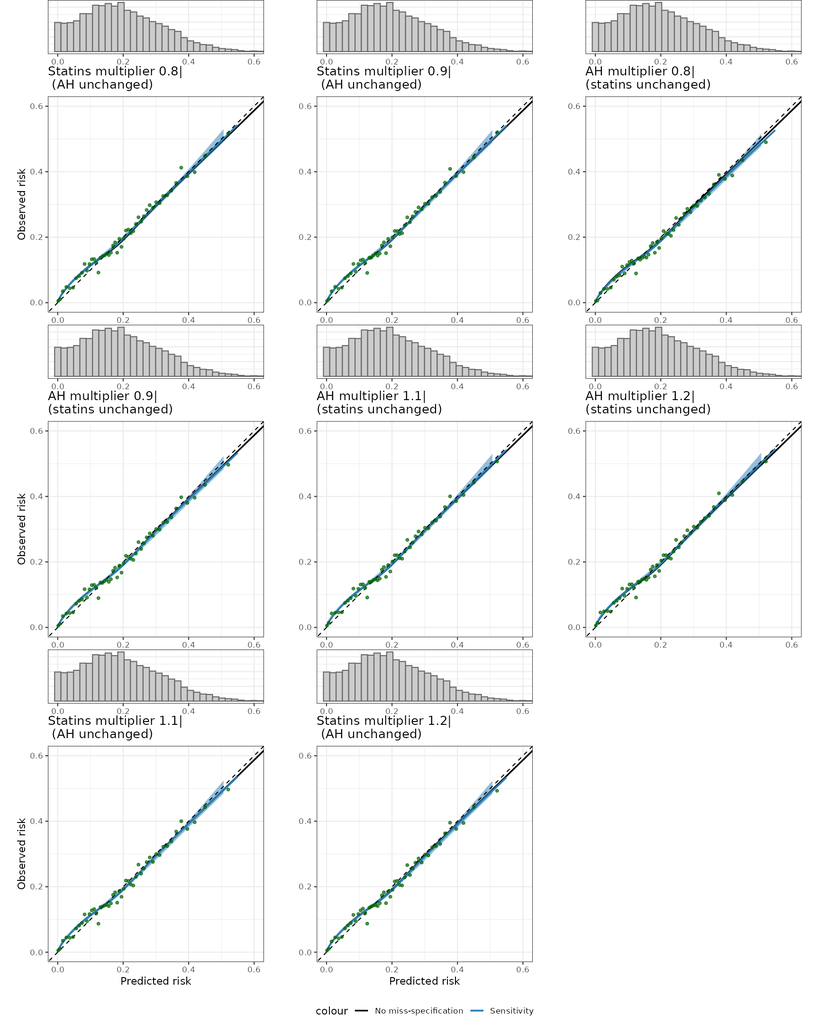

### 2.8.2 Calibration Metrics (ICI, E50, E90)

Saved stratified sensitivity metrics for Men, antihypertensives - on treatment at baseline. No-miss specification is the value from the main analysis, assuming no miss-specification of the treatment effect, but stratified to the same subgroup.

| scenario | metric | value | no miss-specification | difference |
| --- | --- | --- | --- | --- |
| AH multiplier 0.8 (statins unchanged) | E50 | 0.011 | 0.007 | 0.004 |
| AH multiplier 0.9 (statins unchanged) | E50 | 0.009 | 0.007 | 0.002 |
| AH multiplier 1.1 (statins unchanged) | E50 | 0.006 | 0.007 | -0.002 |
| AH multiplier 1.2 (statins unchanged) | E50 | 0.005 | 0.007 | -0.003 |
| Statins multiplier 0.8 (AH unchanged) | E50 | 0.004 | 0.007 | -0.003 |
| Statins multiplier 0.9 (AH unchanged) | E50 | 0.006 | 0.007 | -0.002 |
| Statins multiplier 1.1 (AH unchanged) | E50 | 0.008 | 0.007 | 0.001 |
| Statins multiplier 1.2 (AH unchanged) | E50 | 0.010 | 0.007 | 0.002 |
| AH multiplier 0.8 (statins unchanged) | E90 | 0.017 | 0.018 | -0.001 |
| AH multiplier 0.9 (statins unchanged) | E90 | 0.017 | 0.018 | -0.001 |
| AH multiplier 1.1 (statins unchanged) | E90 | 0.019 | 0.018 | 0.001 |
| AH multiplier 1.2 (statins unchanged) | E90 | 0.020 | 0.018 | 0.002 |
| Statins multiplier 0.8 (AH unchanged) | E90 | 0.019 | 0.018 | 0.001 |
| Statins multiplier 0.9 (AH unchanged) | E90 | 0.019 | 0.018 | 0.001 |
| Statins multiplier 1.1 (AH unchanged) | E90 | 0.018 | 0.018 | 0.000 |
| Statins multiplier 1.2 (AH unchanged) | E90 | 0.017 | 0.018 | -0.001 |
| AH multiplier 0.8 (statins unchanged) | ICI | 0.011 | 0.009 | 0.002 |
| AH multiplier 0.9 (statins unchanged) | ICI | 0.009 | 0.009 | 0.001 |
| AH multiplier 1.1 (statins unchanged) | ICI | 0.008 | 0.009 | -0.001 |
| AH multiplier 1.2 (statins unchanged) | ICI | 0.007 | 0.009 | -0.002 |
| Statins multiplier 0.8 (AH unchanged) | ICI | 0.007 | 0.009 | -0.002 |
| Statins multiplier 0.9 (AH unchanged) | ICI | 0.008 | 0.009 | -0.001 |
| Statins multiplier 1.1 (AH unchanged) | ICI | 0.009 | 0.009 | 0.001 |
| Statins multiplier 1.2 (AH unchanged) | ICI | 0.010 | 0.009 | 0.001 |

### 2.8.3 Discrimination (C-index)

Saved discrimination results for Men, antihypertensives - on treatment at baseline. No-miss specification is the value from the main analysis, assuming no miss-specification of the treatment effect, but stratified to the same subgroup.

| scenario | c_index | lower | upper | no miss-specification | difference |
| --- | --- | --- | --- | --- | --- |
| AH multiplier 0.8 (statins unchanged) | 0.678 | 0.678 | 0.678 | 0.677 | 0.002 |
| AH multiplier 0.9 (statins unchanged) | 0.678 | 0.677 | 0.678 | 0.677 | 0.001 |
| AH multiplier 1.1 (statins unchanged) | 0.676 | 0.676 | 0.676 | 0.677 | -0.001 |
| AH multiplier 1.2 (statins unchanged) | 0.675 | 0.675 | 0.676 | 0.677 | -0.001 |
| Statins multiplier 0.8 (AH unchanged) | 0.677 | 0.677 | 0.677 | 0.677 | 0.000 |
| Statins multiplier 0.9 (AH unchanged) | 0.677 | 0.677 | 0.677 | 0.677 | 0.000 |
| Statins multiplier 1.1 (AH unchanged) | 0.677 | 0.677 | 0.677 | 0.677 | 0.000 |
| Statins multiplier 1.2 (AH unchanged) | 0.676 | 0.676 | 0.677 | 0.677 | 0.000 |